# Multiple Imputation Git

Harrison Kennedy

January 23, 2017

## Step 1 - Inspecting dataset

- Packages Used
  - MICE
  - VIM

**Read in data set**

```r
data <- read.csv("hbat_miss_csv.csv")
```

When dealing with missing data, one must determine if the missing observations you have can be ignored i.e. deleted. To do this, the packages **MICE** and **VIM** are used to check for patterns amongst the missing pieces of information.

The code below uses the **MICE** package and provides details on the quantity of missing data broken down by each pattern. It can be seen that 26 observations are complete, 6 are missing the first variable, and so on.

```r
md.pattern(data[ ,2:dim(data)[2]])
```

```
##    v13 v10 v11 v12 v14 v6 v4 v9 v5 v7 v8 v2 v3 v1
## 26   1   1   1   1   1  1  1  1  1  1  1  1  1  1   0
##  6   1   1   1   1   1  1  1  1  1  1  1  1  1  0   1
##  3   1   1   1   1   1  1  1  1  1  1  1  0  1  1   1
##  1   1   1   1   1   1  1  1  1  1  1  1  1  0  1   1
##  1   1   1   1   1   1  1  0  1  1  1  1  1  1  1   1
##  1   1   1   1   1   1  1  1  1  0  1  1  1  1  1   1
##  1   1   1   1   1   1  1  1  1  1  0  1  1  1  1   1
##  1   1   1   1   1   1  1  1  1  1  1  0  1  1  1   1
##  1   1   1   1   1   1  1  1  0  1  1  1  1  1  1   1
##  2   1   1   1   1   1  1  1  1  1  1  1  0  1  0   2
##  4   1   1   1   1   1  1  1  1  1  1  1  1  0  0   2
##  2   1   1   1   1   1  1  1  1  1  1  1  0  0  1   2
##  1   1   1   1   1   1  1  0  1  1  1  1  1  1  0   2
##  2   1   1   1   1   1  1  0  1  1  1  1  1  0  1   2
```

[output cut: 16 more lines]

Below is a more visual representation of what the **MICE** package shows, using the **VIM** package.

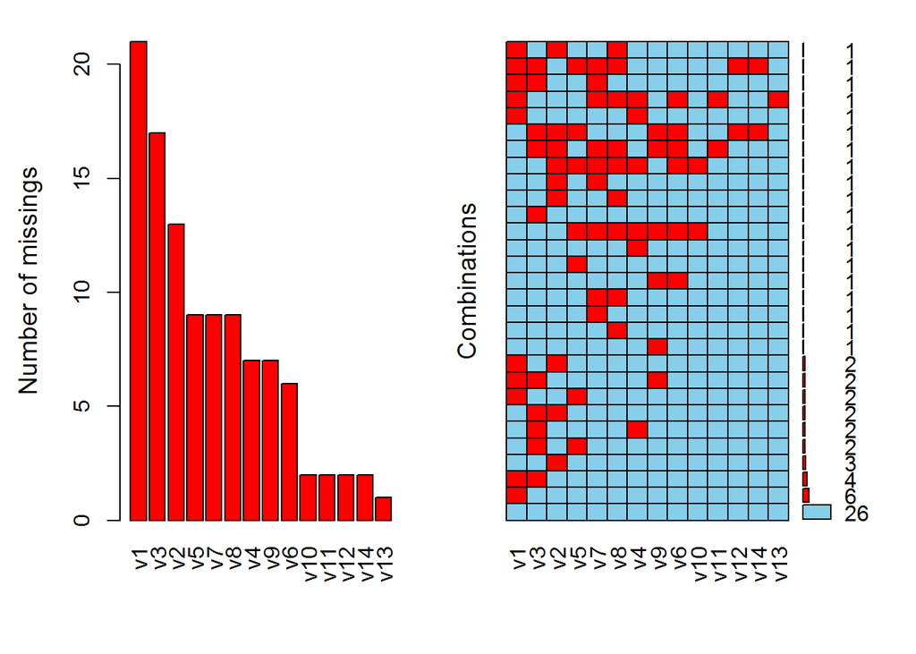

```
##
##  Variables sorted by number of missings:
##  Variable Count
##        v1    21
##        v3    17
##        v2    13
##        v5     9
##        v7     9
##        v8     9
##        v4     7
##        v9     7
##        v6     6
##       v10     2
##       v11     2
##       v12     2
##       v14     2
##       v13     1
```

```r
aggr(data[ ,2:dim(data)[2]], prop = FALSE, sortVars = TRUE, numbers = TRUE)
```

## Step 2 - Identifying Extent of Missing Data

The threshold used in this analysis for “too much” missing data is if an observation has 50% (or more) cases missing. We want to remove these specific observations from our analysis before proceeding with MI. To do this, we want to create a dummy variable indicating if there is a missing case or not. This will be done for each variable in our data frame. These binary variables will be used later to identify the kind of missing data we are dealing with. I have hidden the code for assigning the binary variables v2-v14 from this report.

```r
data$missv1 <- ifelse(is.na(data$v1), 1, 0)
```

Using all of these newly created variables, we are able to create one last variable that adds the binary variables to determine the quantity of missing data for each observations.

```r
data$total_miss <- rowSums(data[16:29])
```

Now that this variable has been created, we want to remove all observations that have a value of 7 or more.

```r
df_reduced <- subset(data, total_miss < 7)
```

## Step 3 - Determining if Data is MCAR, MAR, or MNAR

Depending on the type of missing data we have, will determine if we can use sophisticated data replacement methods or not. The optimal “type” of missing data is MCAR, meaning that there is no rhyme or reason for the missing cases. To test for this, a simple t-test can be used to find out if the mean between the observations with missing cases, are significantly different from the ones without. The dummy variables created in the previous step will be used for this, I will begin testing **missv1**, if the p-value is insignificant there is insufficient evidence to prove that the means and different, therefore we assume the difference between the missing and non-missing groups were negligable.

```r
t.test(v2 ~ missv1, data = df_reduced)
```

```
##
##  Welch Two Sample t-test
##
## data:  v2 by missv1
## t = -0.3047, df = 30.279, p-value = 0.7627
## alternative hypothesis: true difference in means is not equal to 0
## 95 percent confidence interval:
##  -0.5876297  0.4349981
## sample estimates:
## mean in group 0 mean in group 1
##        1.873684        1.950000
```

Based on the resulting p-value of **0.7627** we determine there is no difference between the groups of missing and non-missing data for the variable **v2**, when compared to missing values dummy coded as **missv1**. It is important to note that the tests of significance are done under the assumption of unequal variance (Satterthwaite). If you believe this data does not suffer from heteroscedasticity, you can add the argument **var.equal = TRUE** to see pooled variance output.

This process is repeated for all groupings of variables. Output for variables **v2**-**v9** compared to **missv1** and **v1** and **v2-v9** are shown in comparison to **missv2** below. Each t.test can be run individual or by using the lapply function, which is shown below.

```r
lapply(df_reduced[ ,3:10], function(x) t.test(x ~ df_reduced$missv1))
```

### REMAINING missv1 T-TESTS

```
##
##  Welch Two Sample t-test
##
## data:  v3 by missv1
## t = 1.2663, df = 16.291, p-value = 0.2232
## alternative hypothesis: true difference in means is not equal to 0
## 95 percent confidence interval:
##  -0.4021189  1.5994873
## sample estimates:
## mean in group 0 mean in group 1
##        8.273684        7.675000
```

```
##
##  Welch Two Sample t-test
##
## data:  v4 by missv1
## t = 2.2038, df = 41.893, p-value = 0.03309
## alternative hypothesis: true difference in means is not equal to 0
## 95 percent confidence interval:
##  0.05439042 1.23767308
## sample estimates:
## mean in group 0 mean in group 1
##        5.340476        4.694444
```

```
##
##  Welch Two Sample t-test
##
## data:  v5 by missv1
## t = 2.5989, df = 21.376, p-value = 0.01661
## alternative hypothesis: true difference in means is not equal to 0
## 95 percent confidence interval:
##  0.1270673 1.1393192
## sample estimates:
## mean in group 0 mean in group 1
##        3.021429        2.388235
```

```
##
##  Welch Two Sample t-test
##
## data:  v6 by missv1
## t = 1.8968, df = 38.806, p-value = 0.06531
## alternative hypothesis: true difference in means is not equal to 0
## 95 percent confidence interval:
##  -0.02321047  0.72105736
## sample estimates:
## mean in group 0 mean in group 1
##        2.706818        2.357895
```

```
##
##  Welch Two Sample t-test
##
## data:  v7 by missv1
## t = -1.1205, df = 25.926, p-value = 0.2728
## alternative hypothesis: true difference in means is not equal to 0
## 95 percent confidence interval:
##  -1.6603502  0.4889216
## sample estimates:
## mean in group 0 mean in group 1
##        6.614286        7.200000
```

```
##
##  Welch Two Sample t-test
##
## data:  v8 by missv1
## t = 2.5718, df = 24.779, p-value = 0.01651
## alternative hypothesis: true difference in means is not equal to 0
## 95 percent confidence interval:
##   1.458112 13.208555
## sample estimates:
## mean in group 0 mean in group 1
##        48.16667        40.83333
```

```
##
##  Welch Two Sample t-test
##
## data:  v9 by missv1
## t = 2.0773, df = 23.537, p-value = 0.04886
## alternative hypothesis: true difference in means is not equal to 0
## 95 percent confidence interval:
##  0.002887324 1.059492977
## sample estimates:
## mean in group 0 mean in group 1
##        4.948837        4.417647
```

### missv2 T-TESTS

```
##
##  Welch Two Sample t-test
##
## data:  v1 by missv2
## t = -0.47921, df = 7.0005, p-value = 0.6464
## alternative hypothesis: true difference in means is not equal to 0
## 95 percent confidence interval:
##  -1.512578  1.002804
## sample estimates:
## mean in group 0 mean in group 1
##        3.973684        4.228571
```

```
##
##  Welch Two Sample t-test
##
## data:  v3 by missv2
## t = 0.65307, df = 10.326, p-value = 0.528
## alternative hypothesis: true difference in means is not equal to 0
## 95 percent confidence interval:
##  -0.7634197  1.4003245
## sample estimates:
## mean in group 0 mean in group 1
##        8.180952        7.862500
```

```
##
##  Welch Two Sample t-test
##
## data:  v4 by missv2
## t = -2.2431, df = 12.107, p-value = 0.04437
## alternative hypothesis: true difference in means is not equal to 0
## 95 percent confidence interval:
##  -1.87582453 -0.02817547
## sample estimates:
## mean in group 0 mean in group 1
##           4.988           5.940
```

```
##
##  Welch Two Sample t-test
##
## data:  v5 by missv2
## t = -4.1986, df = 17.811, p-value = 0.000551
## alternative hypothesis: true difference in means is not equal to 0
## 95 percent confidence interval:
##  -1.1944868 -0.3973499
## sample estimates:
## mean in group 0 mean in group 1
##        2.704082        3.500000
```

```
##
##  Welch Two Sample t-test
##
## data:  v6 by missv2
## t = -2.3862, df = 12, p-value = 0.03438
## alternative hypothesis: true difference in means is not equal to 0
## 95 percent confidence interval:
##  -1.15616470 -0.05251454
## sample estimates:
## mean in group 0 mean in group 1
##         2.50566         3.11000
```

```
##
##  Welch Two Sample t-test
##
## data:  v7 by missv2
## t = -1.1867, df = 11, p-value = 0.2603
## alternative hypothesis: true difference in means is not equal to 0
## 95 percent confidence interval:
##  -2.048663  0.613369
## sample estimates:
## mean in group 0 mean in group 1
##        6.682353        7.400000
```

```
##
##  Welch Two Sample t-test
##
## data:  v8 by missv2
## t = -1.0546, df = 9.2561, p-value = 0.3184
## alternative hypothesis: true difference in means is not equal to 0
## 95 percent confidence interval:
##  -11.880952   4.304029
## sample estimates:
## mean in group 0 mean in group 1
##        45.46154        49.25000
```

```
##
##  Welch Two Sample t-test
##
## data:  v9 by missv2
## t = -1.2336, df = 18.582, p-value = 0.2327
## alternative hypothesis: true difference in means is not equal to 0
## 95 percent confidence interval:
##  -0.7179975  0.1859975
## sample estimates:
## mean in group 0 mean in group 1
##           4.754           5.020
```

## Step 4 - Ways to replace missing observations

There are several ways to go about replacing missing values in a data set for use in linear regression. The ones covered in this document are **listwise**, **pairwise correlations**, **mean substitution**, **single imputation**, and **multiple imputation**.

### Listwise Regression

Listwise regression ignores any and all observations that has a case missing from the dataset. This method is as unsophisticated as it gets and in most scenarios should be avoided. It has been included for explanation purposes and as a benchmark when comparing more complex methods of data replacement.

For this dataset, the dependent variable is **v9** and we will be using **v1-v8** as our continuous independent variables. **v10-v14** are factors that will not be used for now.

#### Listwise Regression Results

```r
listwise <- with(df_reduced,lm(v9 ~ v1 + v2 + v3 + v4 + v5 + v6 + v7 + v8))
```